# Final Individual Summary Report

Author

Sebastian Alejos

Published

December 16, 2025

# 1. Introduction and Motivation

Housing quality and housing insecurity are persistent challenges in New York City where aging buildings and socioeconomic inequality intersect. Public complaint systems�particularly NYC�s 311 system�are often used as proxies for housing stress, tenant hardship, and neighborhood-level distress. However, complaint data capture not only underlying housing conditions, but also residents� ability, willingness, and opportunity to report problems.

The overarching research question motivating this project asks: To what extent do neighborhood income levels influence the spatial distribution, types, and resolution outcomes of housing complaints in New York City? My analysis focuses on a specific supporting question within that broader inquiry: Are housing complaints more concentrated in lower-income neighborhoods?

A common assumption in housing policy discourse is that poorer neighborhoods necessarily experience higher volumes of housing complaints, reflecting worse housing conditions. While this may be true in terms of structural deficiencies, complaint data are not a direct measure of conditions; they are a measure of reported problems. Understanding whether complaint concentration aligns with income levels therefore requires careful normalization, spatial analysis, and interpretation.

The data acquired is the 2023 data from multiple NYC Open Data sources combined with American Community Survey (ACS) demographic information. By integrating complaint records with census tract�level income data and normalizing complaint counts by both housing units and population, this study differences between housing stress and reporting behavior. The goal is to assess whether lower-income neighborhoods disproportionately account for reported housing issues once appropriate controls are applied.

# 2. Data Sources and Acquisition

## American Community Survey (ACS)

Neighborhood socioeconomic characteristics are drawn from the 2023 ACS 5-year estimates, accessed programmatically via the “tidycensus” package. Data are collected at the census tract level, which provides a balance between spatial granularity and statistical reliability.

The following variables are used:

- Median household income
- Total population
- Total housing units
- Rent burden indicator

Census tracts are spatially represented as polygons and reprojected into a standard geographic coordinate system (EPSG: 4326) to enable spatial joins with point-based complaint data.

ACS data serve two critical roles in the analysis. First, median household income is the key independent variable used to classify neighborhoods and construct income quintiles. Second, population and housing unit counts are used to normalize complaint volumes, allowing for fair comparison across tracts of very different sizes and densities.

```r
# Load Required Libraries & Define ACS Variables

# Load core libraries for ACS and data manipulation
library(tidycensus)
library(tidyverse)
library(sf)

# Define ACS variables we will pull: income, rent burden, housing units, population
vars <- c(
  income        = "B19013_001E",
  rent_burden   = "B25070_001E",
  housing_units = "B25002_001E",
  population    = "B01003_001E"
)

# NYC’s five counties (boroughs)
nyc_counties <- c("New York", "Kings", "Queens", "Bronx", "Richmond")

# Pull ACS (American Community Survey) Data for All NYC Census Tracts
acs_tracts_sf <- get_acs(
  geography = "tract",
  variables = vars,
  year      = 2023,
  survey    = "acs5",
  state     = "NY",
  county    = nyc_counties,
  output    = "wide",
  key       = "8511c605b287c092b9895c821043632a80c83008",
  geometry  = TRUE   # <-- important
) %>%
  st_transform(4326) # match lat/lon CRS
head(acs_tracts_sf)
```

```
Simple feature collection with 6 features and 10 fields
Geometry type: MULTIPOLYGON
Dimension:     XY
Bounding box:  xmin: -73.90606 ymin: 40.82439 xmax: -73.84726 ymax: 40.90264
Geodetic CRS:  WGS 84
        GEOID                                        NAME income B19013_001M
1 36005023502 Census Tract 235.02; Bronx County; New York  47484        8551
2 36005013500    Census Tract 135; Bronx County; New York  30865       26467
3 36005009200     Census Tract 92; Bronx County; New York  56913       14039
4 36005005400     Census Tract 54; Bronx County; New York  58452       19753
5 36005036501 Census Tract 365.01; Bronx County; New York  54097       27972
6 36005044902 Census Tract 449.02; Bronx County; New York  99250       23563
  rent_burden B25070_001M housing_units B25002_001M population B01003_001M
1        1567         173          1645         178       4284         896
2        1418         218          1505         221       3295         699
3        1350         216          1970         150       5675         696
4        1415         241          1942         219       5306         834
5        1399         152          1484         141       4721         765
6         650         133           957         109       2303         368
                        geometry
1 MULTIPOLYGON (((-73.906 40....
2 MULTIPOLYGON (((-73.90508 4...
3 MULTIPOLYGON (((-73.85773 4...
4 MULTIPOLYGON (((-73.88389 4...
5 MULTIPOLYGON (((-73.88832 4...
6 MULTIPOLYGON (((-73.87136 4...
```

## NYC 311 Housing Complaints

Housing complaints are drawn from the NYC 311 Service Requests dataset, accessed through the Socrata Open Data API using the RSocrata package. Records are limited to complaints created during calendar year 2023 to maintain temporal consistency with ACS estimates and other HPD and DOB datasets.

The 311 records include:

- Complaint type and descriptor
- Creation and closure timestamps
- Incident address and ZIP code
- Latitude and longitude coordinates

Complaint records are cleaned to standardize column names, parse date fields, and extract time-based features such as year, month, and day of week. Records lacking valid geographic coordinates are excluded from spatial analyses, as they cannot be reliably assigned to census tracts. The 311 dataset is the primary source used to measure reported housing complaints. My analysis focuses on housing-related complaints, including issues such as heat and hot water, maintenance, and habitability concerns.

```r
# install.packages("devtools")
# devtools::install_github("Chicago/RSocrata")
# Load libraries for scraping NYC Open Data via Socrata API
library("RSocrata")
library(janitor)
library(lubridate)
library(dplyr)

# NYC Open Data application token
app_token <- "ExUt22WiPiJvXNo3ZwPuIUDuC"

# Build the API URL to pull 311 complaints for all of 2023
url_311 <- paste0(
  "https://data.cityofnewyork.us/resource/erm2-nwe9.json?",
  "$select=unique_key,created_date,closed_date,complaint_type,descriptor,",
  "incident_address,incident_zip,borough,latitude,longitude",
  "&$where=created_date >= '2023-01-01T00:00:00' ",
  "AND created_date < '2024-01-01T00:00:00'",
  "&$limit=50000"
)

# Download 311 data, clean names, and create date-based variables
nyc311 <- read.socrata(url_311, app_token = app_token) %>%
  clean_names() %>%
  mutate(
    created_date = ymd_hms(created_date),
    closed_date  = ymd_hms(closed_date),
    date         = as_date(created_date),
    year         = year(created_date),
    month        = month(created_date),
    dow          = wday(created_date, label = TRUE)
  )


head(nyc311)
```

```
  unique_key        created_date         closed_date complaint_type
1   57488375 2023-05-02 20:51:21 2023-05-04 08:14:22 HEAT/HOT WATER
2   57507916 2023-05-04 21:11:44 2023-05-05 14:12:51 HEAT/HOT WATER
3   57515626 2023-05-05 19:58:49 2023-05-06 09:59:29 HEAT/HOT WATER
4   57521531 2023-05-06 18:58:52 2023-05-07 18:24:40 HEAT/HOT WATER
5   57647184 2023-05-18 10:59:07 2023-05-18 15:39:26 HEAT/HOT WATER
6   57630427 2023-05-17 14:26:19 2023-05-19 15:35:56     WATER LEAK
       descriptor           incident_address incident_zip   borough
1  APARTMENT ONLY              1494 1 AVENUE        10075 MANHATTAN
2 ENTIRE BUILDING           2324 BOSTON ROAD        10467     BRONX
3 ENTIRE BUILDING     2600 NETHERLAND AVENUE        10463     BRONX
4  APARTMENT ONLY           1825 BOSTON ROAD        10460     BRONX
5 ENTIRE BUILDING 773 CONCOURSE VILLAGE EAST        10451     BRONX
6      HEAVY FLOW       353 WEST   44 STREET        10036 MANHATTAN
            latitude          longitude       date year month dow
1  40.77155905845877  -73.9532462599786 2023-05-02 2023     5 Tue
2 40.860289246119095 -73.86716509774867 2023-05-04 2023     5 Thu
3  40.87874357609838 -73.91567866115459 2023-05-05 2023     5 Fri
4 40.838877939751406 -73.88520910453818 2023-05-06 2023     5 Sat
5  40.82300985183132 -73.91988269473408 2023-05-18 2023     5 Thu
6  40.75916465037001 -73.99031890410726 2023-05-17 2023     5 Wed
```

## Downloading & Cleaning DOB (Department of Buildings) Complaints (2023)

To contextualize 311 complaints within the broader enforcement ecosystem, the analysis also incorporates: Housing Preservation and Development (HPD) violations, filtered to Class A, B, and C violations issued in 2023 & Department of Buildings (DOB) complaints, also filtered to 2023.

While these datasets are not the primary focus of the supporting question, they inform interpretation by distinguishing between resident-reported complaints and formal inspection or enforcement actions. HPD data are cleaned by parsing multiple date fields, constructing Borough�Block�Lot (BBL) identifiers, and filtering to valid records with complete geographic information.

```r
# NYC Open Data application token
app_token <- "ExUt22WiPiJvXNo3ZwPuIUDuC"

# DOB complaint dataset (CSV format from NYC Open Data)
url_dob <- "https://data.cityofnewyork.us/resource/vztk-gaf7.csv?$limit=50000"

dob_raw <- read.socrata(url_dob, app_token = app_token)

# Clean DOB data: fix timestamps, parse dates, create address
dob_clean <- dob_raw %>%
  clean_names() %>%
  mutate(
    date_entered     = mdy(date_entered),
    inspection_date  = mdy(inspection_date),
    disposition_date = mdy(disposition_date),

    # Fix: dobrundate is stored as large integer representing Unix milliseconds
    dobrundate = as.POSIXct(dobrundate / 1000,
                            origin = "1970-01-01",
                            tz = "UTC"),
    # Create additional time fields + a unified full address string
    date  = date_entered,
    year  = year(date_entered),
    month = month(date_entered),
    dow   = wday(date_entered, label = TRUE),
    full_address = paste0(house_number, " ", house_street, ", NY ", zip_code)
  )

# Filter DOB complaints to 2023 only
dob_complaints_2023 <- dob_clean %>%
  filter(
    !is.na(date),
    date >= as.Date("2023-01-01"),
    date < as.Date("2024-01-01")
  ) %>%
  select(
    complaint_number,
    status,
    date_entered,
    inspection_date,
    disposition_date,
    full_address,
    complaint_category,
    year, month, dow
  )

nrow(dob_complaints_2023)
```

```
[1] 2195
```

```r
head(dob_complaints_2023)
```

```
  complaint_number status date_entered inspection_date disposition_date
1          3917187 CLOSED   2023-07-05      2023-07-05       2023-07-05
2          4928802 CLOSED   2023-06-20      2024-04-09       2024-04-09
3          1626850 CLOSED   2023-01-18      2023-01-19       2023-01-19
4          3901856 CLOSED   2023-04-20      2023-04-21       2023-04-24
5          1632966 CLOSED   2023-03-31      2023-04-03       2023-04-04
6          2379096 CLOSED   2023-10-25      2023-11-06       2023-11-06
                      full_address complaint_category year month dow
1     135 WYCKOFF AVENUE, NY 11237                 7J 2023     7 Wed
2 258-02 HILLSIDE AVENUE, NY 11004                 4S 2023     6 Tue
3       1638 PARK AVENUE, NY 10029                 7F 2023     1 Wed
4       8812 BAY PARKWAY, NY 11214                 6S 2023     4 Thu
5       230 LENOX AVENUE, NY 10027                 23 2023     3 Fri
6  1168 STRATFORD AVENUE, NY 10472                 1Y 2023    10 Wed
```

# 3. Data Cleaning, Processing, and Integration

## Temporal and Spatial Consistency

A key design choice in my analysis is restricting all datasets to the year 2023. Doing so avoids inconsistencies that arise when complaint data and socioeconomic data are drawn from mismatched time periods. While ACS 5-year estimates reflect conditions averaged over multiple years, using the most recent available ACS release ensures reasonable temporal alignment.

Spatial integration is performed at the census tract level. Individual 311 complaints are converted to spatial point objects and joined to tract polygons using a within-geometry spatial join. This step assigns each complaint a unique tract GEOID, enabling aggregation and normalization.

```r
# ============================================================
# Load packages for NYC Open Data (HPD, 311, DOB) and wrangling
#    - RSocrata: access NYC Open Data via API
#    - janitor: clean column names
#    - lubridate: handle dates/times
#    - dplyr: data manipulation
# ============================================================

# install.packages("devtools")
# devtools::install_github("Chicago/RSocrata")
library("RSocrata")
library(janitor)
library(lubridate)
library(dplyr)

# NYC Open Data app token (used by RSocrata API calls)
app_token <- "ExUt22WiPiJvXNo3ZwPuIUDuC"


# ============================================================
# HPD Violations: Download & clean Housing Preservation & Development data
#    - Pull up to 100,000 rows of HPD violations
#    - Parse dates, build BBL, derive basic time fields (year, month, dow)
# ============================================================


url_hpd <- "https://data.cityofnewyork.us/resource/wvxf-dwi5.csv?$limit=100000"

hpd_raw <- read.socrata(url_hpd, app_token = app_token)

names(hpd_raw)
```

```
 [1] "violationid"           "buildingid"            "registrationid"
 [4] "boroid"                "boro"                  "housenumber"
 [7] "lowhousenumber"        "highhousenumber"       "streetname"
[10] "streetcode"            "zip"                   "apartment"
[13] "story"                 "block"                 "lot"
[16] "class"                 "inspectiondate"        "approveddate"
[19] "originalcertifybydate" "originalcorrectbydate" "newcertifybydate"
[22] "newcorrectbydate"      "certifieddate"         "ordernumber"
[25] "novid"                 "novdescription"        "novissueddate"
[28] "currentstatusid"       "currentstatus"         "currentstatusdate"
[31] "novtype"               "violationstatus"       "rentimpairing"
[34] "latitude"              "longitude"             "communityboard"
[37] "councildistrict"       "censustract"           "bin"
[40] "bbl"                   "nta"
```

```r
hpd_clean <- hpd_raw %>%
  clean_names() %>%
  mutate(
    # Parse all relevant date columns
    novissueddate           = ymd(novissueddate),
    inspectiondate          = ymd(inspectiondate),
    approveddate            = ymd(approveddate),
    originalcertifybydate   = ymd(originalcertifybydate),
    originalcorrectbydate   = ymd(originalcorrectbydate),
    newcertifybydate        = ymd(newcertifybydate),
    newcorrectbydate        = ymd(newcorrectbydate),
    certifieddate           = ymd(certifieddate),
    currentstatusdate       = ymd(currentstatusdate),

    # Use NOV issued date as the main event date
    date  = novissueddate,
    year  = year(date),
    month = month(date),
    dow   = wday(date, label = TRUE),

    # Convert Boro/Block/Lot to integers (suppress parsing warnings)
    boroid = suppressWarnings(as.integer(boroid)),
    block  = suppressWarnings(as.integer(block)),
    lot    = suppressWarnings(as.integer(lot)),

    # Build BBL as a zero-padded string: [boro][block][lot]
    bbl = if_else(
      !is.na(boroid) & !is.na(block) & !is.na(lot),
      sprintf("%01d%05d%04d", boroid, block, lot),
      NA_character_
    )
  )


# ============================================================
# Filter HPD violations to 2023 & valid records
#    - Keep only class A/B/C violations with non-missing BBL and borough
# ============================================================


hpd_filtered <- hpd_clean %>%
  filter(
    !is.na(date),
    date >= as.Date("2023-01-01"),
    date <  as.Date("2024-01-01"),
    class %in% c("A", "B", "C"),
    !is.na(bbl),
    !is.na(boro)
  )
```

## Address-Level Aggregation

Before tract-level aggregation, complaint and enforcement data are also aggregated at the address level. A standardized full_address field is constructed for each dataset to support joins across 311, DOB, and HPD records. This allows the analysis to capture how multiple reporting systems intersect at the same physical locations. Address-level aggregation is particularly important for understanding whether high complaint volumes reflect repeated reporting at a small number of problematic buildings versus widespread issues across many locations.

```r
# ============================================================
# Aggregate HPD violations by BBL + Class
#    - hpd_by_bbl_class: counts and dates per BBL–class combination
# ============================================================

hpd_by_bbl_class <- hpd_filtered %>%
  group_by(bbl, class) %>%
  summarize(
    n_violations = n(),
    first_date   = min(date, na.rm = TRUE),
    last_date    = max(date, na.rm = TRUE),
    n_buildings  = n_distinct(buildingid),
    .groups      = "drop"
  )

# ============================================================
# Aggregate HPD violations by BBL + Class + address
#    - Capture one canonical address per BBL–class
#    - Build full_address string for joining to 311/DOB
# ============================================================

hpd_by_bbl_class_addr <- hpd_filtered %>%
  arrange(date) %>%
  group_by(bbl, class) %>%
  summarize(
    boro         = first(boro),
    housenumber  = first(housenumber),
    streetname   = first(streetname),
    zip          = first(zip),
    novdescription = first(novdescription),
    n_violations = n(),
    first_date   = min(date, na.rm = TRUE),
    last_date    = max(date, na.rm = TRUE),
    .groups      = "drop"
  ) %>%
  mutate(
    full_address = paste0(housenumber, " ", streetname, ", ", boro, " NY ", zip)
  )

head(hpd_by_bbl_class_addr)
```

```
# A tibble: 6 × 11
  bbl       class boro  housenumber streetname   zip novdescription n_violations
  <chr>     <chr> <chr> <chr>       <chr>      <int> <chr>                 <int>
1 10030000… B     MANH… 44          ELDRIDGE … 10002 § 27-2005 ADM…            3
2 10054000… B     MANH… 120         MAC DOUGA… 10012 § 27-2045 ADM…            2
3 10054000… C     MANH… 120         MAC DOUGA… 10012 § 27-2005 ADM…            1
4 10106600… B     MANH… 421         WEST 56 S… 10019 § 27-2005 ADM…            1
5 10119900… B     MANH… 8           WEST 86 S… 10024 § 27-2005 ADM…            2
6 10146801… B     MANH… 403         EAST 73 S… 10021 § 27-2026, 20…            4
# ℹ 3 more variables: first_date <date>, last_date <date>, full_address <chr>
```

```r
# ============================================================
# Address-level joins: 311, DOB, HPD
#    - Goal: Build a unified address table with counts from all three sources
# ============================================================

library(dplyr)
library(janitor)
library(lubridate)

# Construct full_address for 311 and aggregate by address
nyc3112 <- nyc311 %>%
  mutate(
    full_address = paste0(incident_address, ", NY ", incident_zip)
  )

addr_311 <- nyc3112 %>%
  group_by(full_address) %>%
  summarize(
    n_311      = n(),
    n_311_heat = sum(complaint_type == "HEAT/HOT WATER", na.rm = TRUE),
    first_311  = min(date, na.rm = TRUE),
    last_311   = max(date, na.rm = TRUE),
    .groups    = "drop"
  )

# Aggregate DOB complaints by address (from dob_complaints_2023)
addr_dob <- dob_complaints_2023 %>%
  group_by(full_address) %>%
  summarize(
    n_dob          = n(),
    n_dob_open     = sum(status != "CLOSED", na.rm = TRUE),
    median_res_dob = median(disposition_date - date_entered, na.rm = TRUE),
    .groups        = "drop"
  )

# Join 311 and DOB at the address level
addr_311_dob <- addr_311 %>%
  left_join(addr_dob, by = "full_address")

# Add HPD counts at the address level
addr_311_dob_hpd <- addr_311_dob %>%
  left_join(
    hpd_by_bbl_class_addr %>%
      group_by(full_address) %>%
      summarize(
        n_hpd   = n(),
        n_hpd_c = sum(class == "C", na.rm = TRUE),
        .groups = "drop"
      ),
    by = "full_address"
  )
```

## Normalization and Derived Metrics

Raw complaint counts are insufficient for meaningful comparison. Two primary normalization strategies are used:

Complaints per 1,000 housing units, capturing the intensity of complaints relative to the housing stock

Complaints per 1,000 residents, capturing reporting frequency relative to population

In addition, census tracts are grouped into income quintiles based on median household income. This facilitates comparison across the income distribution while avoiding arbitrary income thresholds.

```r
# ============================================================
# Tract-level story: join point-based 311 data to census tracts
#    - Convert 311 complaints to sf points
#    - Spatially join to ACS tract polygons
#    - Aggregate up to tract level for SQ1–SQ4 & SQ6
# ============================================================
library(sf)
library(dplyr)

# Convert 311 complaints to point geometry
nyc311_sf <- nyc311 %>%
  filter(!is.na(longitude), !is.na(latitude)) %>%
  st_as_sf(coords = c("longitude", "latitude"), crs = 4326)

# Spatial join: attach tract GEOID to each 311 complaint
nyc311_with_tract <- st_join(
  nyc311_sf,
  acs_tracts_sf %>% select(GEOID),
  join = st_within
)

# Aggregate 311 counts by census tract
tract_311 <- nyc311_with_tract %>%
  st_drop_geometry() %>%
  group_by(GEOID) %>%
  summarize(
    n_311      = n(),
    n_311_heat = sum(complaint_type == "HEAT/HOT WATER", na.rm = TRUE),
    .groups    = "drop"
  )

# Merge ACS tract attributes with 311 tract-level counts
tract_311_acs <- acs_tracts_sf %>%
  left_join(tract_311, by = "GEOID")
```

# 4. Exploratory Data Analysis and Visualization

## Spatial Distribution of Complaint Density

The first set of visualizations examines the spatial distribution of housing complaints across New York City. Choropleth maps of complaint density per 1,000 housing units reveal clear geographic clustering.

High complaint densities appear in parts of the Bronx and northern Brooklyn�areas that tend to have older housing stock and higher proportions of renters. When normalized by housing units, these neighborhoods stand out as areas of concentrated housing stress.

```r
# ============================================================
# SQ1 Setup: Are housing complaints more concentrated in lower-income neighborhoods?
#    - Re-load required libs (for safety in isolated execution)
#    - Rebuild 311 sf points & join GEOID (if needed)
#    - Aggregate complaints at tract level
# ============================================================

library(sf)
library(dplyr)
library(tidycensus)
library(ggplot2)
library(janitor)
library(lubridate)

# Ensure 311 sf object exists (convert again to include lon/lat columns)
nyc311_sf <- nyc311 %>%
  filter(!is.na(longitude), !is.na(latitude)) %>%
  st_as_sf(coords = c("longitude", "latitude"), crs = 4326, remove = FALSE)

# Spatial join: attach tract GEOID to each 311 complaint
nyc311_with_tract <- st_join(
  nyc311_sf,
  acs_tracts_sf %>% select(GEOID),
  join = st_within
)

# Aggregate 311 complaints by tract (total + heat complaints)
tract_311 <- nyc311_with_tract %>%
  st_drop_geometry() %>%
  group_by(GEOID) %>%
  summarize(
    complaints_311  = n(),
    complaints_heat = sum(complaint_type == "HEAT/HOT WATER", na.rm = TRUE),
    .groups         = "drop"
  )

#  Join ACS data to 311 complaint counts at tract level
tract_master <- acs_tracts_sf %>%
  left_join(tract_311, by = "GEOID") %>%
  mutate(
    complaints_per_1000_units = (complaints_311 / housing_units) * 1000,
    income_quintile           = ntile(income, 5)
  )
```

Bright yellow zones in northern Brooklyn and the Bronx mark tracts with the highest complaint rates, highlighting hotspots of housing stress or active reporting. Dark blue zones in Staten Island, southern Queens, and parts of Manhattan show fewer complaints per housing unit. The map reflects complaint intensity, not just raw volume.

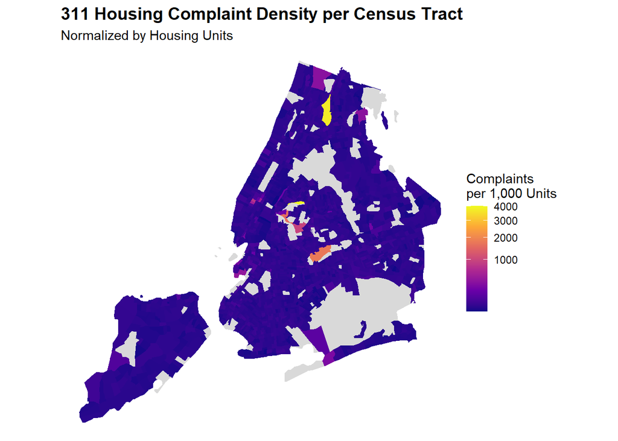

```r
# ============================================================
# SQ1 Visualization: Choropleth of complaint density per housing unit
# ============================================================

ggplot(tract_master) +
  geom_sf(aes(fill = complaints_per_1000_units), color = NA) +
  scale_fill_viridis_c(
    option   = "plasma",       # clearer color gradient
    trans    = "sqrt",         # softens skew in complaint rates
    na.value = "grey85",
    name     = "Complaints\nper 1,000 Units"
  ) +
  labs(
    title    = "311 Housing Complaint Density per Census Tract",
    subtitle = "Normalized by Housing Units"
  ) +
  theme_void() +               # removes axes and background clutter
  theme(
    legend.position = "right",
    plot.title      = element_text(size = 14, face = "bold"),
    plot.subtitle   = element_text(size = 11)
  )
```

The graph below shows a positive correlation between the median household income and 311 housing complaints density per 1,000 units. As income increases, complaint rates tend to rise slightly. Higher Income neighborhoods may report more complaints, lower income areas do not show disproportionately high complaint rates.

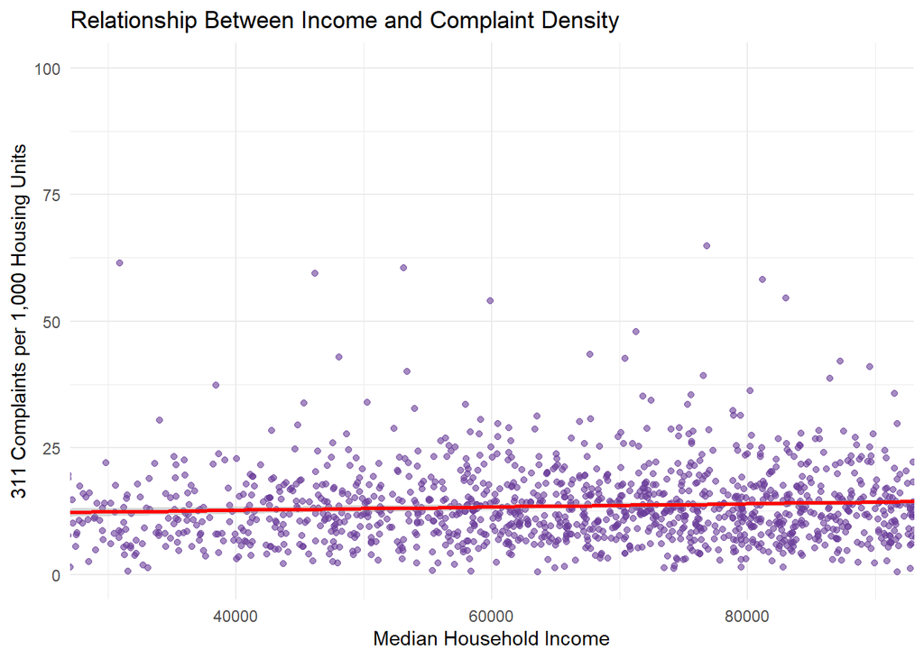

```r
# ============================================================
# Clean extreme tracts and explore Income vs Complaint Density
#     - Filter out tracts with very few units or extreme rates
# ============================================================

tract_clean <- tract_master %>%
  filter(
    housing_units >= 100,
    complaints_per_1000_units <= 200
  )

ggplot(tract_clean, aes(x = income, y = complaints_per_1000_units)) +
  geom_point(alpha = 0.6, color = "#6A3D9A") +
  geom_smooth(method = "lm", se = TRUE, color = "red") +
  coord_cartesian(xlim = c(30000, 90000), ylim = c(0, 100)) +  # adjust as needed
  labs(
    title = "Relationship Between Income and Complaint Density",
    x     = "Median Household Income",
    y     = "311 Complaints per 1,000 Housing Units"
  ) +
  theme_minimal()
```